# International Flight Forecasting

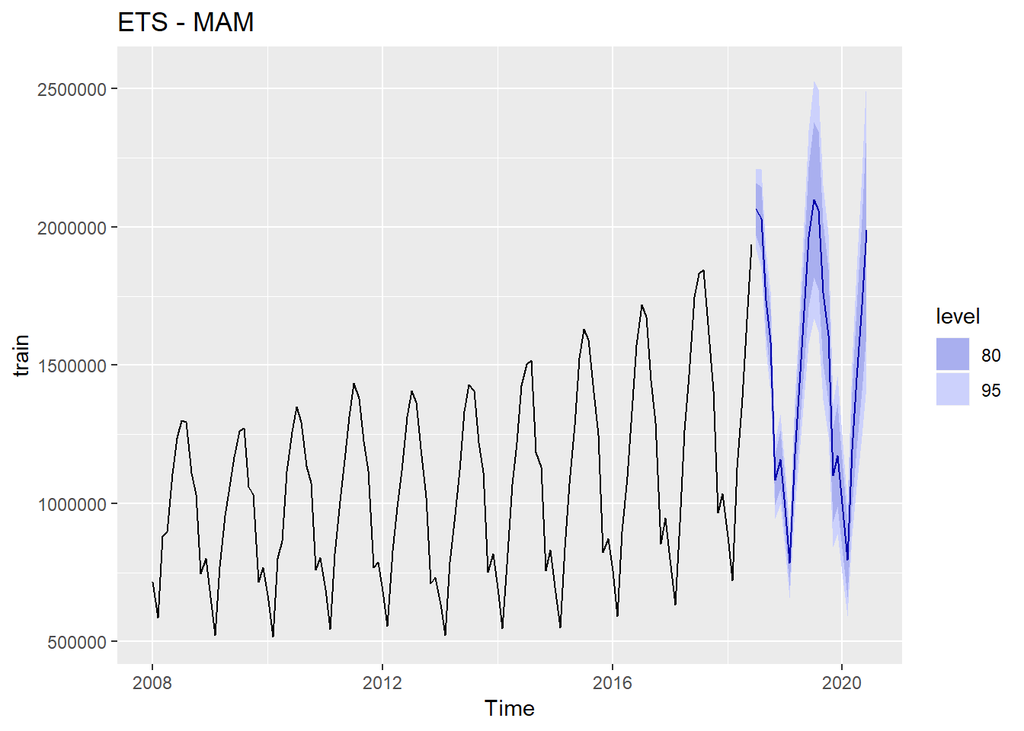

```
## ETS(M,Ad,M)
##
## Call:
##  ets(y = train, model = "MAM")
##
##   Smoothing parameters:
##     alpha = 0.7558
##     beta  = 0.0062
##     gamma = 1e-04
##     phi   = 0.9777
##
##   Initial states:
##     l = 1023297.7947
##     b = -2262.537
##     s = 0.785 0.7372 1.0767 1.1813 1.3832 1.4098
##            1.3215 1.1426 0.968 0.7966 0.5307 0.6675
##
##   sigma:  0.0359
##
##      AIC     AICc      BIC
## 3273.247 3279.639 3324.300
##
## Training set error measures:
##                   ME     RMSE      MAE       MPE     MAPE      MASE
## Training set 4714.92 35958.65 25281.32 0.3450024 2.393413 0.4069762
##                    ACF1
## Training set -0.0564455
```

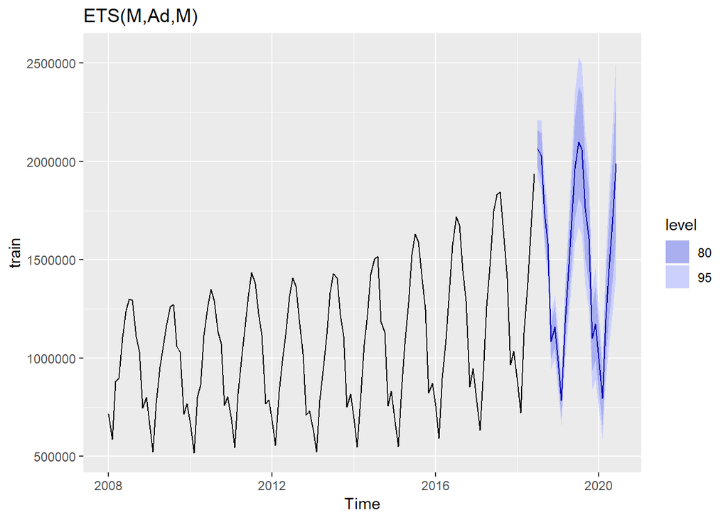

```
## ETS(M,Ad,M)
##
## Call:
##  ets(y = train, model = "ZZZ")
##
##   Smoothing parameters:
##     alpha = 0.7558
##     beta  = 0.0062
##     gamma = 1e-04
##     phi   = 0.9777
##
##   Initial states:
##     l = 1023297.7947
##     b = -2262.537
##     s = 0.785 0.7372 1.0767 1.1813 1.3832 1.4098
##            1.3215 1.1426 0.968 0.7966 0.5307 0.6675
##
##   sigma:  0.0359
##
##      AIC     AICc      BIC
## 3273.247 3279.639 3324.300
##
## Training set error measures:
##                   ME     RMSE      MAE       MPE     MAPE      MASE
## Training set 4714.92 35958.65 25281.32 0.3450024 2.393413 0.4069762
##                    ACF1
## Training set -0.0564455
```

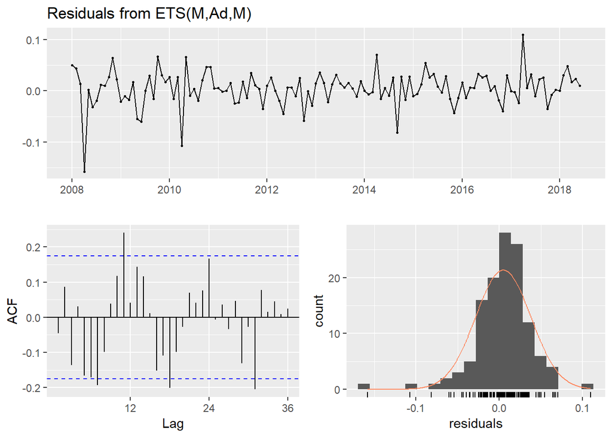

```
##
##  Ljung-Box test
##
## data:  Residuals from ETS(M,Ad,M)
## Q* = 52.359, df = 7, p-value = 4.96e-09
##
## Model df: 17.   Total lags used: 24
```

```
##                    ME     RMSE      MAE       MPE     MAPE      MASE
## Training set  4714.92 35958.65 25281.32 0.3450024 2.393413 0.4069762
## Test set     59890.33 89410.83 62377.01 3.8130139 3.946629 1.0041388
##                    ACF1 Theil's U
## Training set -0.0564455        NA
## Test set      0.5515216 0.2900773
```

```
##                      ME      RMSE       MAE        MPE      MAPE      MASE
## Training set   4720.584  46864.94  34369.72  0.3300935  3.302626 0.5532804
## Test set     -94545.374 171051.47 135512.58 -9.7492477 11.714521 2.1814680
##                    ACF1 Theil's U
## Training set 0.04490566        NA
## Test set     0.65493258 0.7428515
```

```
##                     ME     RMSE      MAE       MPE     MAPE      MASE
## Training set  4669.134 35897.27 25308.33 0.3287808 2.394707 0.4074109
## Test set     55354.659 84627.46 58476.46 3.5078162 3.680772 0.9413483
##                     ACF1 Theil's U
## Training set -0.02861872        NA
## Test set      0.53564499  0.272581
```

```
##                      ME      RMSE       MAE        MPE      MAPE     MASE
## Training set   4410.507  48254.26  35326.47  0.2640174  3.419934 0.568682
## Test set     -59309.069 157440.58 128378.53 -7.2038709 10.626490 2.066625
##                    ACF1 Theil's U
## Training set 0.06622826        NA
## Test set     0.64504634 0.6497716
```

```
##                     ME     RMSE      MAE       MPE     MAPE      MASE
## Training set  3842.729 35628.41 24905.46 0.3159739 2.376534 0.4009256
## Test set     39822.985 70208.79 48639.90 2.4979209 3.038618 0.7830002
##                     ACF1 Theil's U
## Training set -0.05422164        NA
## Test set      0.52714618 0.2290267
```

```
##                    ME     RMSE      MAE       MPE     MAPE      MASE
## Training set  4714.92 35958.65 25281.32 0.3450024 2.393413 0.4069762
## Test set     59890.33 89410.83 62377.01 3.8130139 3.946629 1.0041388
##                    ACF1 Theil's U
## Training set -0.0564455        NA
## Test set      0.5515216 0.2900773
```

Calling the “ZZZ” gave us optimal model for MAM, however AAM looks like it has the lowest errors and best accuracy across the models. Lets try to optimize this model by finding the best gamma.

#### optimizing the gamma

We will attempt to optimize the parameters here, we use the AAM model that minimized our prediction errors above (MAPE) and identify the gamma parameter that minimizes forecast errors. In this case we see that gamma = 0.06 minimizes the error rate.

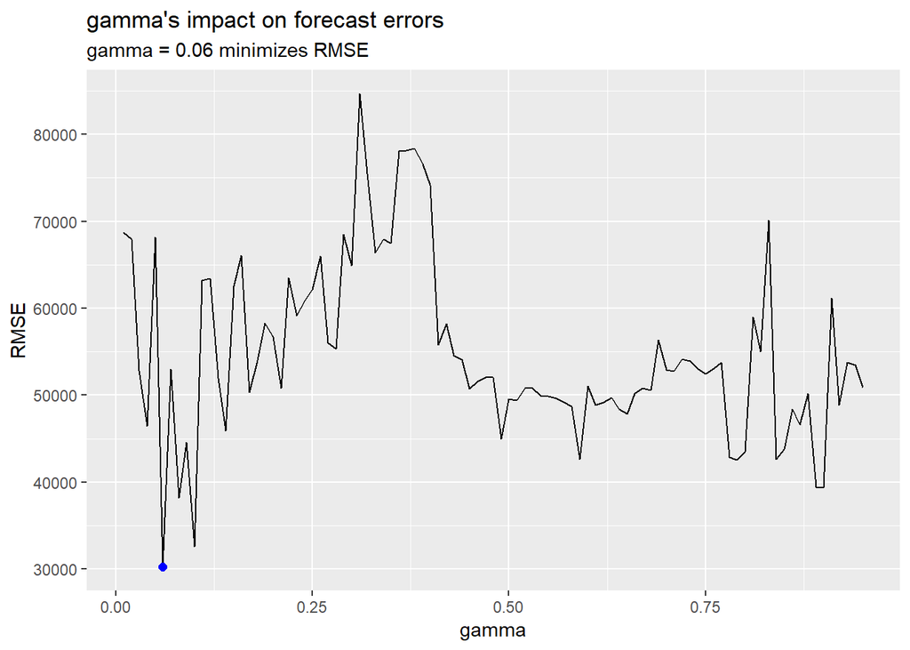

```
##                     ME     RMSE      MAE       MPE     MAPE      MASE
## Training set  3842.729 35628.41 24905.46 0.3159739 2.376534 0.4009256
## Test set     39822.985 70208.79 48639.90 2.4979209 3.038618 0.7830002
##                     ACF1 Theil's U
## Training set -0.05422164        NA
## Test set      0.52714618 0.2290267
```

```
##                    ME     RMSE      MAE       MPE     MAPE      MASE
## Training set 3071.692 36992.85 26041.99 0.1720018 2.516764 0.4192214
## Test set     6848.922 30226.03 25549.42 0.3100556 1.738506 0.4112920
##                     ACF1 Theil's U
## Training set -0.06640101        NA
## Test set      0.04159174 0.1150258
```

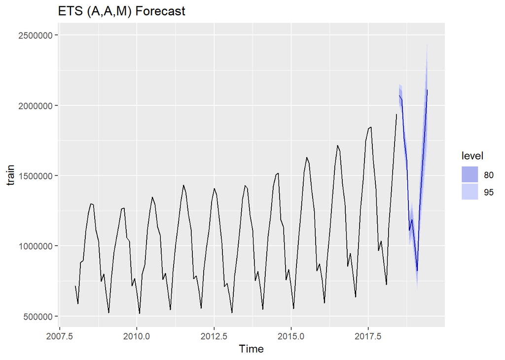

Updating our model with this “optimal” gamma 0.06, we see that we bring our forecasting error rate down from 3.04% to 1.74%.

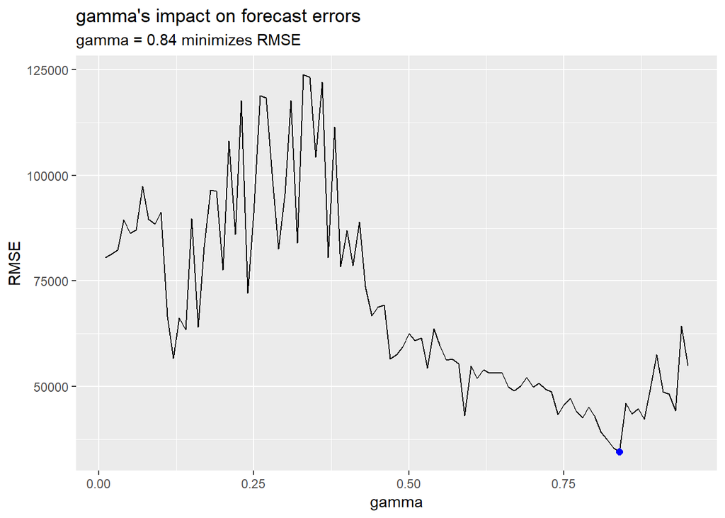

```
## # A tibble: 1 x 2
##   gamma   RMSE
##   <dbl>  <dbl>
## 1  0.84 34466.
```

```
##                    ME     RMSE      MAE       MPE     MAPE      MASE
## Training set  4714.92 35958.65 25281.32 0.3450024 2.393413 0.4069762
## Test set     59890.33 89410.83 62377.01 3.8130139 3.946629 1.0041388
##                    ACF1 Theil's U
## Training set -0.0564455        NA
## Test set      0.5515216 0.2900773
```

```
##                    ME     RMSE      MAE       MPE     MAPE      MASE
## Training set  6027.22 43494.86 31704.68 0.2631622 2.991448 0.5103787
## Test set     15633.55 34465.81 29820.88 1.2045690 2.093456 0.4800536
##                     ACF1 Theil's U
## Training set  0.28670421        NA
## Test set     -0.07837003 0.1234351
```

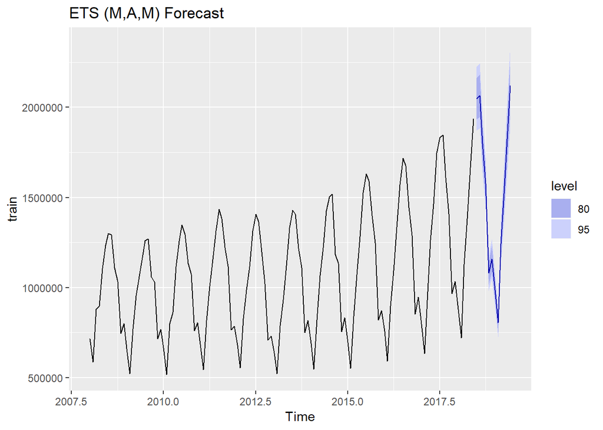

```
##                     ME     RMSE      MAE         MPE     MAPE      MASE
## Training set  6975.356 40755.04 31173.21  0.36865882 2.953685 0.5018232
## Test set     -1457.605 62414.95 50371.63 -0.07026508 2.998235 0.8108775
##                    ACF1 Theil's U
## Training set 0.07726602        NA
## Test set     0.51788740 0.1852378
```

```
##
## Forecast method: ETS(M,Ad,M)
##
## Model Information:
## ETS(M,Ad,M)
##
## Call:
##  ets(y = train, model = "MAM", damped = TRUE, gamma = 0.84, phi = 0.85)
##
##   Smoothing parameters:
##     alpha = 0.1599
##     beta  = 0.0911
##     gamma = 0.84
##     phi   = 0.85
##
##   Initial states:
##     l = 1023297.7196
##     b = -4322.7805
##     s = 0.82 0.7661 1.1062 1.1514 1.2953 1.3146
##            1.2669 1.1316 0.9213 0.9 0.6036 0.7229
##
##   sigma:  0.0419
##
##      AIC     AICc      BIC
## 3307.687 3312.678 3353.067
##
## Error measures:
##                    ME     RMSE      MAE       MPE     MAPE      MASE
## Training set 6975.356 40755.04 31173.21 0.3686588 2.953685 0.5018232
##                    ACF1
## Training set 0.07726602
##
## Forecasts:
##          Point Forecast     Lo 80     Hi 80     Lo 95     Hi 95
## Jul 2018      2096213.3 1983720.5 2208706.1 1924170.4 2268256.2
## Aug 2018      2129956.4 2012161.8 2247750.9 1949805.2 2310107.5
## Sep 2018      1866027.6 1757858.6 1974196.7 1700597.3 2031457.9
## Oct 2018      1638267.3 1537399.5 1739135.0 1484003.3 1792531.2
## Nov 2018      1119491.2 1045667.8 1193314.5 1006588.1 1232394.2
## Dec 2018      1192345.7 1107803.3 1276888.1 1063049.3 1321642.1
## Jan 2019      1007364.8  930519.9 1084209.7  889840.6 1124889.0
## Feb 2019       814376.4  747645.2  881107.5  712319.9  916432.9
## Mar 2019      1241796.3 1132802.7 1350790.0 1075104.9 1408487.7
## Apr 2019      1498658.6 1358249.1 1639068.1 1283920.8 1713396.4
## May 2019      1780708.1 1603280.7 1958135.6 1509356.2 2052060.0
## Jun 2019      2055382.6 1838389.7 2272375.4 1723520.6 2387244.5
```

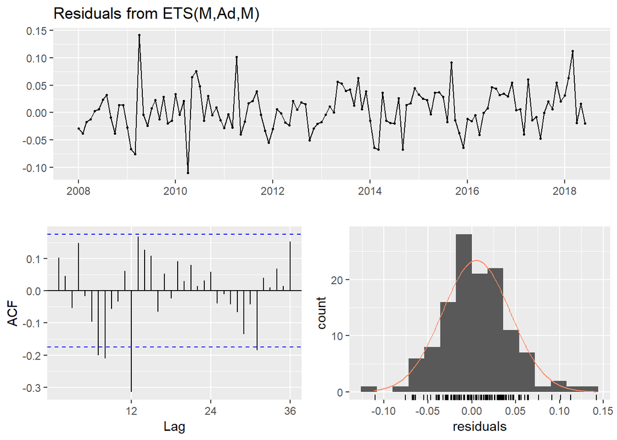

```
##
##  Ljung-Box test
##
## data:  Residuals from ETS(M,Ad,M)
## Q* = 45.135, df = 7, p-value = 1.288e-07
##
## Model df: 17.   Total lags used: 24
```

[interactive chart not shown]

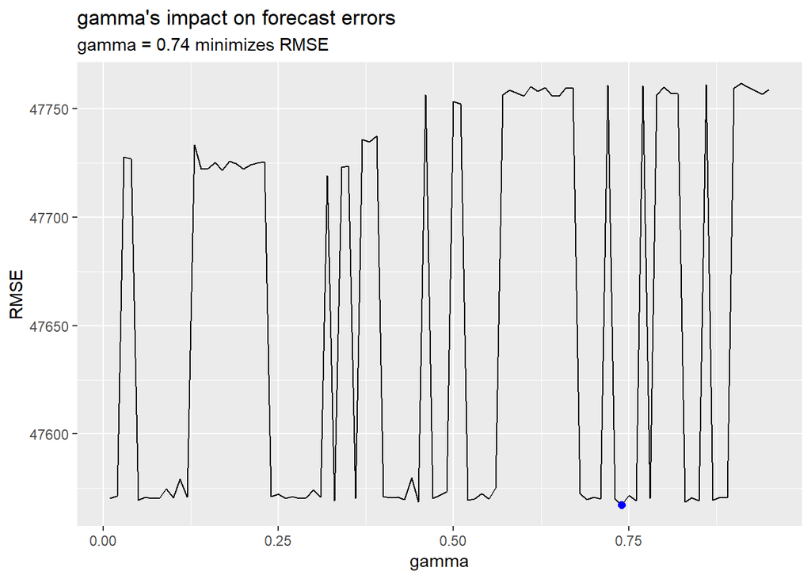

```
##
## Forecast method: ETS(A,N,N)
##
## Model Information:
## ETS(A,N,N)
##
## Call:
##  ets(y = train_diff, gamma = 0.74)
##
##   Smoothing parameters:
##     alpha = 1e-04
##
##   Initial states:
##     l = 1093.178
##
##   sigma:  52131.22
##
##      AIC     AICc      BIC
## 3349.438 3349.635 3357.947
##
## Error measures:
##                     ME     RMSE      MAE      MPE     MAPE      MASE
## Training set -65.38595 51506.87 37191.66 99.62111 105.7432 0.6030404
##                    ACF1
## Training set -0.4786222
##
## Forecasts:
##          Point Forecast     Lo 80    Hi 80     Lo 95    Hi 95
## Jul 2018       1092.243 -65716.61 67901.09 -101083.1 103267.6
## Aug 2018       1092.243 -65716.61 67901.09 -101083.1 103267.6
## Sep 2018       1092.243 -65716.61 67901.09 -101083.1 103267.6
## Oct 2018       1092.243 -65716.61 67901.09 -101083.1 103267.6
## Nov 2018       1092.243 -65716.61 67901.09 -101083.1 103267.6
## Dec 2018       1092.243 -65716.61 67901.10 -101083.1 103267.6
## Jan 2019       1092.243 -65716.61 67901.10 -101083.1 103267.6
## Feb 2019       1092.243 -65716.61 67901.10 -101083.1 103267.6
## Mar 2019       1092.243 -65716.61 67901.10 -101083.1 103267.6
## Apr 2019       1092.243 -65716.61 67901.10 -101083.1 103267.6
## May 2019       1092.243 -65716.61 67901.10 -101083.1 103267.6
## Jun 2019       1092.243 -65716.61 67901.10 -101083.1 103267.6
```

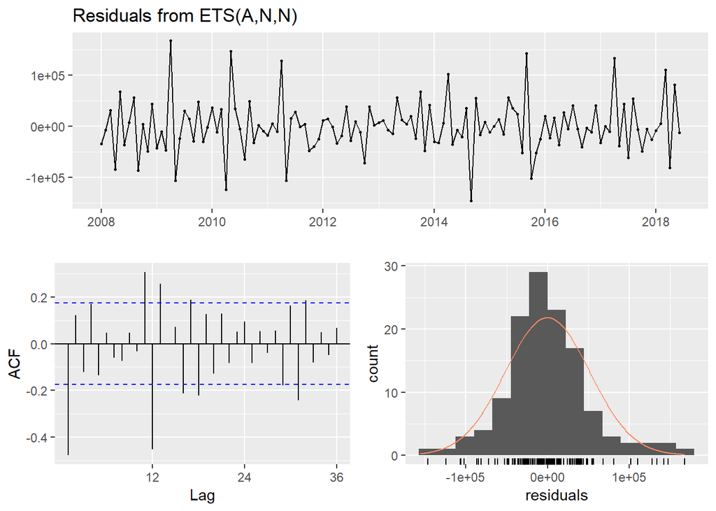

```
##
##  Ljung-Box test
##
## data:  Residuals from ETS(A,N,N)
## Q* = 124.05, df = 21, p-value < 2.2e-16
##
## Model df: 3.   Total lags used: 24
```

[interactive chart not shown]

#### TBATS

```
##
## Forecast method: TBATS(0.001, {0,0}, -, {<12,5>})
##
## Model Information:
## TBATS(0.001, {0,0}, -, {<12,5>})
##
## Call: tbats(y = train)
##
## Parameters
##   Lambda: 0.000504
##   Alpha: 0.7688448
##   Gamma-1 Values: 0.001036519
##   Gamma-2 Values: 0.01148451
##
## Seed States:
##              [,1]
##  [1,] 13.80606744
##  [2,] -0.40393571
##  [3,] -0.02109420
##  [4,]  0.01510737
##  [5,]  0.03783220
##  [6,]  0.02078098
##  [7,] -0.04217150
##  [8,] -0.03239655
##  [9,] -0.05271246
## [10,] -0.06677604
## [11,] -0.06103466
## attr(,"lambda")
## [1] 0.0005044655
##
## Sigma: 0.03496429
## AIC: 3277.855
##
## Error measures:
##                   ME     RMSE      MAE       MPE     MAPE      MASE
## Training set 6172.75 37654.02 26146.16 0.3534106 2.447341 0.4208982
##                     ACF1
## Training set -0.04514903
##
## Forecasts:
##          Point Forecast     Lo 80     Hi 80     Lo 95   Hi 95
## Jul 2018      2073544.2 1983331.2 2167858.5 1937174.3 2219509
## Aug 2018      2012730.1 1902638.2 2129188.9 1846816.8 2193540
## Sep 2018      1751549.0 1638291.6 1872631.9 1581330.6 1940080
## Oct 2018      1578256.6 1464112.6 1701294.7 1407067.4 1770262
## Nov 2018      1086065.4  999836.1 1179727.4  956994.6 1232534
## Dec 2018      1155357.3 1056445.2 1263525.2 1007558.1 1324825
## Jan 2019       992742.9  901986.9 1092625.4  857350.4 1149504
## Feb 2019       784278.0  708374.9  868309.6  671213.3  916377
## Mar 2019      1191371.7 1070134.4 1326336.5 1011030.0 1403863
## Apr 2019      1420447.7 1269159.0 1589760.4 1195704.7 1687408
## May 2019      1686554.7 1499523.4 1896900.6 1409059.4 2018666
## Jun 2019      1924342.7 1702656.1 2174876.4 1595830.7 2320440
```

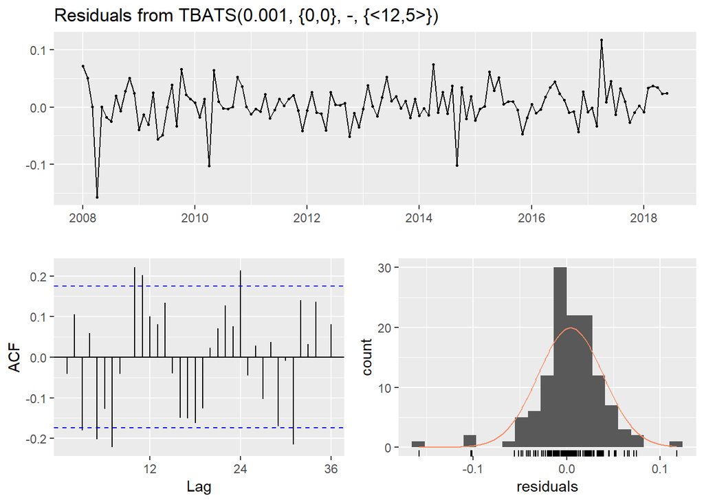

```
##
##  Ljung-Box test
##
## data:  Residuals from TBATS(0.001, {0,0}, -, {<12,5>})
## Q* = 63.235, df = 9, p-value = 3.176e-10
##
## Model df: 15.   Total lags used: 24
```

[interactive chart not shown]

```
##
## Forecast method: BATS(1, {0,1}, -, -)
##
## Model Information:
## BATS(1, {0,1}, -, -)
##
## Call: tbats(y = train_diff)
##
## Parameters
##   Alpha: 0.02366732
##   MA coefficients: -0.532312
##
## Seed States:
##           [,1]
## [1,] -5240.743
## [2,]     0.000
##
## Sigma: 45263.95
## AIC: 3318.879
##
## Error measures:
##                    ME     RMSE      MAE      MPE     MAPE      MASE
## Training set 5439.608 45263.95 33207.25 94.49645 214.9444 0.5384356
##                     ACF1
## Training set -0.05578232
##
## Forecasts:
##          Point Forecast     Lo 80    Hi 80     Lo 95     Hi 95
## Jul 2018      -8802.533 -66810.61 49205.55 -97518.24  79913.17
## Aug 2018       2345.798 -62735.01 67426.60 -97186.71 101878.30
## Sep 2018       2345.798 -62738.18 67429.77 -97191.55 101883.15
## Oct 2018       2345.798 -62741.34 67432.94 -97196.39 101887.99
## Nov 2018       2345.798 -62744.51 67436.11 -97201.24 101892.83
## Dec 2018       2345.798 -62747.68 67439.27 -97206.08 101897.68
## Jan 2019       2345.798 -62750.84 67442.44 -97210.92 101902.52
## Feb 2019       2345.798 -62754.01 67445.61 -97215.77 101907.36
## Mar 2019       2345.798 -62757.18 67448.77 -97220.61 101912.20
## Apr 2019       2345.798 -62760.34 67451.94 -97225.45 101917.05
## May 2019       2345.798 -62763.51 67455.10 -97230.29 101921.89
## Jun 2019       2345.798 -62766.68 67458.27 -97235.14 101926.73
```

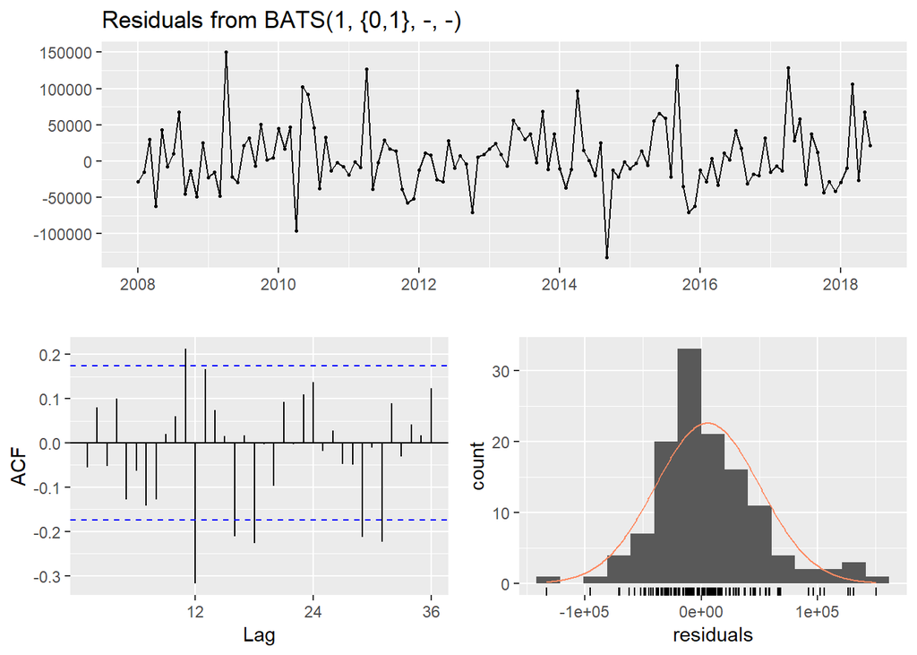

```
##
##  Ljung-Box test
##
## data:  Residuals from BATS(1, {0,1}, -, -)
## Q* = 58.459, df = 20, p-value = 1.23e-05
##
## Model df: 4.   Total lags used: 24
```

```
##                    ME     RMSE      MAE       MPE     MAPE      MASE
## Training set 5439.608 45263.95 33207.25  94.49645 214.9444 0.5384356
## Test set     1806.980 48159.46 39018.41 102.52528 102.5253 0.6326601
##                     ACF1 Theil's U
## Training set -0.05578232        NA
## Test set     -0.36549456 0.8787949
```

```
##  Time-Series [1:126] from 2008 to 2018: 715523 585945 880755 896799 1106916 ...
```

```
## Observations: 126
## Variables: 2
## $ train <dbl> 715523, 585945, 880755, 896799, 1106916, 1236107, 129970...
## $ date  <dbl> 2008.000, 2008.083, 2008.167, 2008.250, 2008.333, 2008.4...
```

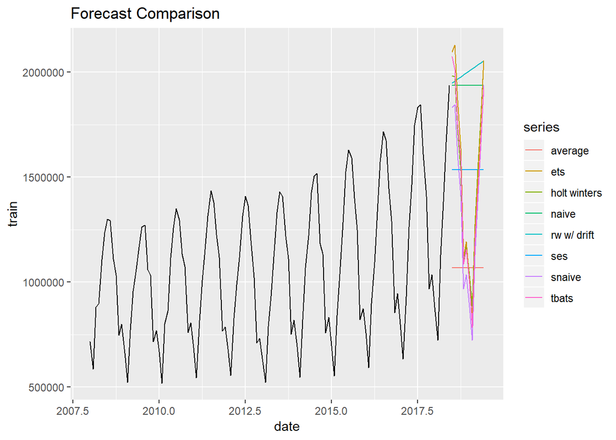

```
## Observations: 126
## Variables: 2
## $ train_diff <dbl> -33577, -5857, 31992, -82944, 68885, -35343, 8747, ...
## $ date       <dbl> 2008.000, 2008.083, 2008.167, 2008.250, 2008.333, 2...
```

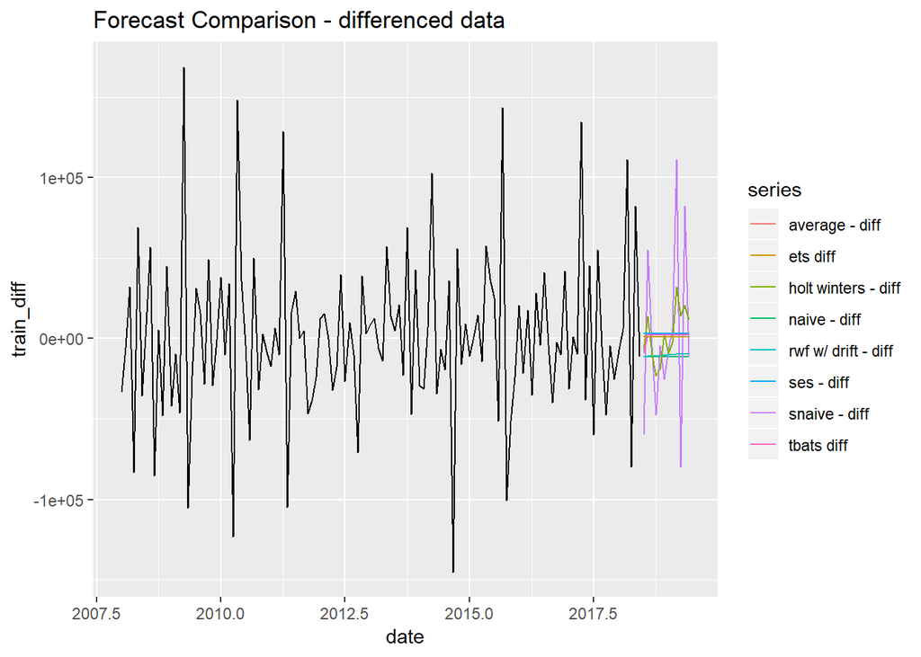

#### Arima

```
## AR/MA
##   0 1 2 3
## 0 x o o o
## 1 x x o o
## 2 x x o o
## 3 x o o x
```

```
## Series: train_diff
## ARIMA(1,1,0)
##
## Coefficients:
##           ar1
##       -0.7035
## s.e.   0.0630
##
## sigma^2 estimated as 3.996e+09:  log likelihood=-1558.99
## AIC=3121.99   AICc=3122.09   BIC=3127.64
```

```
## Series: train_diff
## ARIMA(1,1,3)
##
## Coefficients:
##           ar1      ma1      ma2     ma3
##       -0.7357  -0.8234  -0.4660  0.2896
## s.e.   0.1925   0.2161   0.3138  0.1366
##
## sigma^2 estimated as 2.041e+09:  log likelihood=-1518.38
## AIC=3046.76   AICc=3047.26   BIC=3060.9
```

```
## Series: train_diff
## ARIMA(2,1,0)
##
## Coefficients:
##           ar1      ar2
##       -0.9906  -0.4099
## s.e.   0.0814   0.0822
##
## sigma^2 estimated as 3.354e+09:  log likelihood=-1547.72
## AIC=3101.44   AICc=3101.64   BIC=3109.93
```

```
## Series: train_diff
## ARIMA(2,1,1)
##
## Coefficients:
##           ar1      ar2    ma1
##       -0.5369  -0.1321  -1.00
## s.e.   0.0889   0.0894   0.03
##
## sigma^2 estimated as 2.069e+09:  log likelihood=-1519.56
## AIC=3047.12   AICc=3047.45   BIC=3058.43
```

```
## Series: train_diff
## ARIMA(2,1,2)
##
## Coefficients:
##           ar1      ar2      ma1      ma2
##       -1.4396  -0.4881  -0.0291  -0.9709
## s.e.   0.0805   0.0771   0.0437   0.0432
##
## sigma^2 estimated as 2.077e+09:  log likelihood=-1519.33
## AIC=3048.66   AICc=3049.17   BIC=3062.8
```

```
## Series: train_diff
## ARIMA(2,1,3)
##
## Coefficients:
##           ar1      ar2      ma1      ma2     ma3
##       -1.1944  -0.2439  -0.3550  -0.9704  0.3255
## s.e.   0.1792   0.1781   0.1875   0.0532  0.1826
##
## sigma^2 estimated as 2.048e+09:  log likelihood=-1518.14
## AIC=3048.28   AICc=3049   BIC=3065.25
```

```
## Series: train_diff
## ARIMA(3,1,1)
##
## Coefficients:
##           ar1      ar2      ar3      ma1
##       -0.5582  -0.2151  -0.1529  -1.0000
## s.e.   0.0886   0.1005   0.0891   0.0397
##
## sigma^2 estimated as 2.032e+09:  log likelihood=-1518.11
## AIC=3046.22   AICc=3046.72   BIC=3060.36
```

```
## Series: train_diff
## ARIMA(3,1,2)
##
## Coefficients:
##           ar1      ar2      ar3      ma1      ma2
##       -0.9156  -0.4094  -0.2075  -0.6311  -0.3689
## s.e.   0.3287   0.1971   0.0914   0.3324   0.3306
##
## sigma^2 estimated as 2.038e+09:  log likelihood=-1517.75
## AIC=3047.5   AICc=3048.21   BIC=3064.47
```

```
## Series: train_diff
## ARIMA(3,1,3)
##
## Coefficients:
##           ar1      ar2      ar3     ma1      ma2      ma3
##       -2.0393  -1.6118  -0.4652  0.7083  -0.7083  -1.0000
## s.e.   0.0795   0.1423   0.0844  0.0441   0.0529   0.0438
##
## sigma^2 estimated as 1.862e+09:  log likelihood=-1513.72
## AIC=3041.44   AICc=3042.39   BIC=3061.23
```

Based on eacf(), ARIMA(3,1,3) has the best AICc

```
##
## Forecast method: ARIMA(3,1,3)(1,1,2)[12]
##
## Model Information:
## Series: train_diff
## ARIMA(3,1,3)(1,1,2)[12]
## Box Cox transformation: lambda= -0.002124992
##
## Coefficients:
##          ar1      ar2     ar3      ma1     ma2      ma3    sar1     sma1
##       0.6443  -0.9216  0.4029  -1.6075  1.6075  -1.0000  0.3209  -1.0629
## s.e.  0.2030   0.1329  0.1652   0.3856  0.4397   0.3835  0.4594   0.5223
##         sma2
##       0.0629
## s.e.  0.4871
##
## sigma^2 estimated as 0.3445:  log likelihood=-78.15
## AIC=176.29   AICc=178.45   BIC=203.57
##
## Error measures:
##                    ME     RMSE      MAE       MPE     MAPE      MASE
## Training set 4263.326 23925.05 15166.98 -48.88288 91.06193 0.2459235
##                    ACF1
## Training set 0.07078766
##
## Forecasts:
##          Point Forecast     Lo 80     Hi 80     Lo 95      Hi 95
## Jul 2018      45584.692 16096.478 129392.60  9285.687  224992.62
## Aug 2018      27184.262 10350.549  71537.53  6213.246  119490.47
## Sep 2018      62990.251 21029.609 189159.76 11777.873  338909.52
## Oct 2018      81656.205 25839.778 258770.27 14068.802  477074.27
## Nov 2018      21966.456  6804.712  71118.21  3663.532  132614.78
## Dec 2018      27779.556  9163.280  84437.93  5099.490  152259.85
## Jan 2019      24444.411  7987.892  75003.96  4423.435  135927.17
## Feb 2019       5263.406  1927.963  14400.17  1133.918   24554.66
## Mar 2019      67717.651 24782.991 185431.93 14569.209  316339.54
## Apr 2019     192925.283 61671.240 605199.99 33757.353 1109748.08
## May 2019      77856.974 28457.940 213465.85 16718.515  364408.53
## Jun 2019      38707.919 12673.974 118533.20  7025.772  214586.69
```

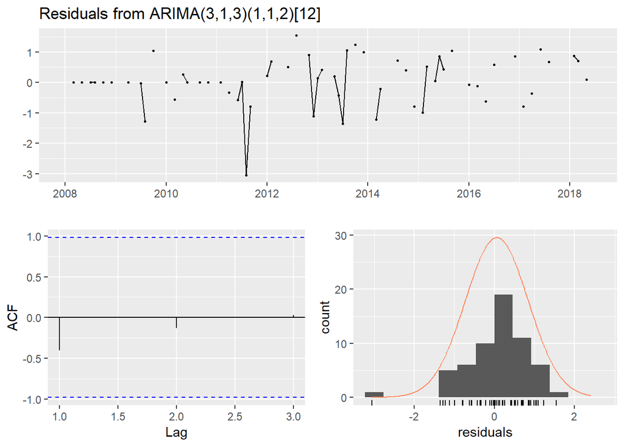

```
##
##  Ljung-Box test
##
## data:  Residuals from ARIMA(3,1,3)(1,1,2)[12]
## Q* = 60.055, df = 15, p-value = 2.468e-07
##
## Model df: 9.   Total lags used: 24
```

#### auto.arima

- Notes:
  - At lag 11 there is a spike in the ACF plot for the residuals. We expect this to be the multiple seasonality that we visualized in our EDA.

```
##
## Forecast method: ARIMA(1,1,0)(2,1,0)[12]
##
## Model Information:
## Series: train
## ARIMA(1,1,0)(2,1,0)[12]
## Box Cox transformation: lambda= -0.002124992
##
## Coefficients:
##           ar1     sar1     sar2
##       -0.4129  -0.7213  -0.2288
## s.e.   0.0869   0.0977   0.1051
##
## sigma^2 estimated as 0.001154:  log likelihood=221.18
## AIC=-434.36   AICc=-433.99   BIC=-423.45
##
## Error measures:
##                    ME     RMSE      MAE       MPE     MAPE      MASE
## Training set 4285.081 34430.15 24297.48 0.2807745 2.301882 0.3911383
##                     ACF1
## Training set -0.08742943
##
## Forecasts:
##          Point Forecast     Lo 80     Hi 80     Lo 95     Hi 95
## Jul 2018      2097934.6 2005811.8 2194297.8 1958697.3 2247092.3
## Aug 2018      2059238.8 1954759.9 2169314.4 1901619.8 2229952.4
## Sep 2018      1791845.3 1683826.4 1906809.3 1629311.5 1970630.6
## Oct 2018      1589549.5 1482990.0 1703783.2 1429509.6 1767548.8
## Nov 2018      1061201.2  983137.9 1145477.2  944170.5 1192772.6
## Dec 2018      1153708.2 1062146.3 1253181.3 1016661.7 1309273.1
## Jan 2019       982410.9  899145.8 1073404.6  857969.6 1124945.1
## Feb 2019       783881.7  713538.4  861175.8  678898.5  905138.9
## Mar 2019      1179718.7 1068184.5 1302926.1 1013484.6 1373286.3
## Apr 2019      1518458.5 1368037.5 1685457.8 1294550.8 1781190.0
## May 2019      1799941.6 1613925.5 2007448.2 1523383.2 2126832.9
## Jun 2019      2126476.1 1898017.4 2382499.1 1787208.6 2530309.6
```

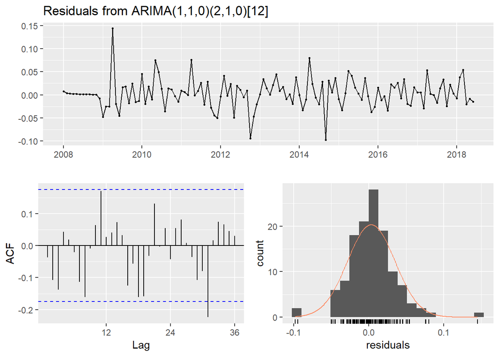

```
##
##  Ljung-Box test
##
## data:  Residuals from ARIMA(1,1,0)(2,1,0)[12]
## Q* = 29.596, df = 21, p-value = 0.1004
##
## Model df: 3.   Total lags used: 24
```

#### VAR

```
## [1] "validation_report" "cpiai_csv"         "cpiai_json"
## [4] "cpi-us_zip"        "cpiai"
```

```
##         Date Index Inflation
## 1 1913-01-01   9.8        NA
## 2 1913-02-01   9.8      0.00
## 3 1913-03-01   9.8      0.00
## 4 1913-04-01   9.8      0.00
## 5 1913-05-01   9.7     -1.02
## 6 1913-06-01   9.8      1.03
```

[figure not shown]

[figure not shown]

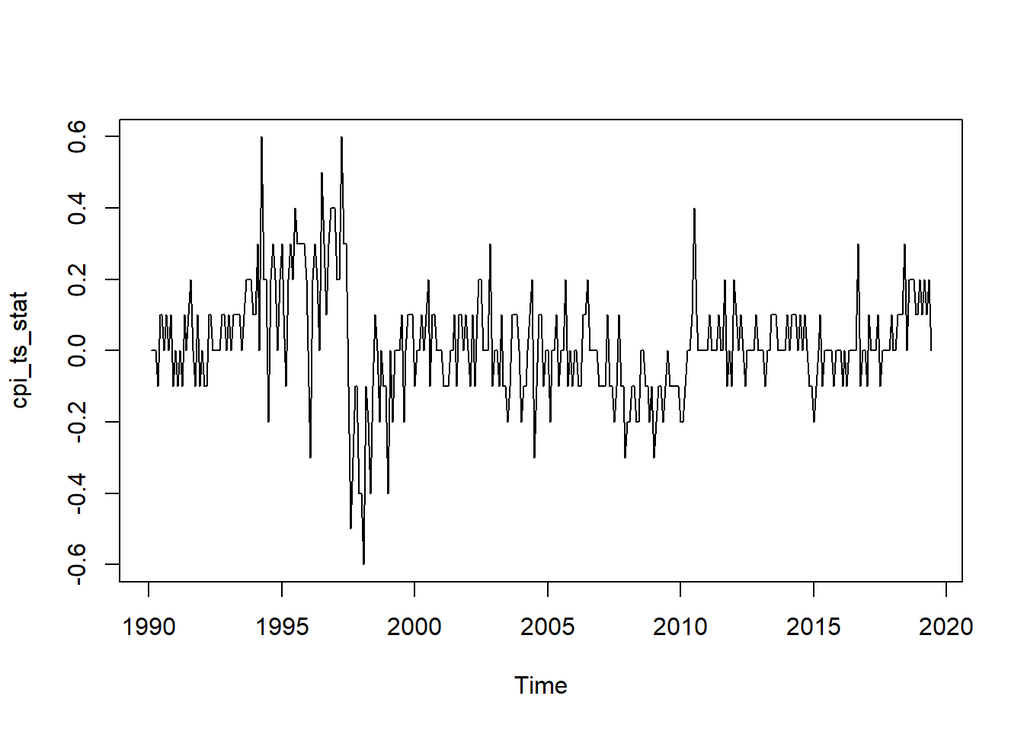

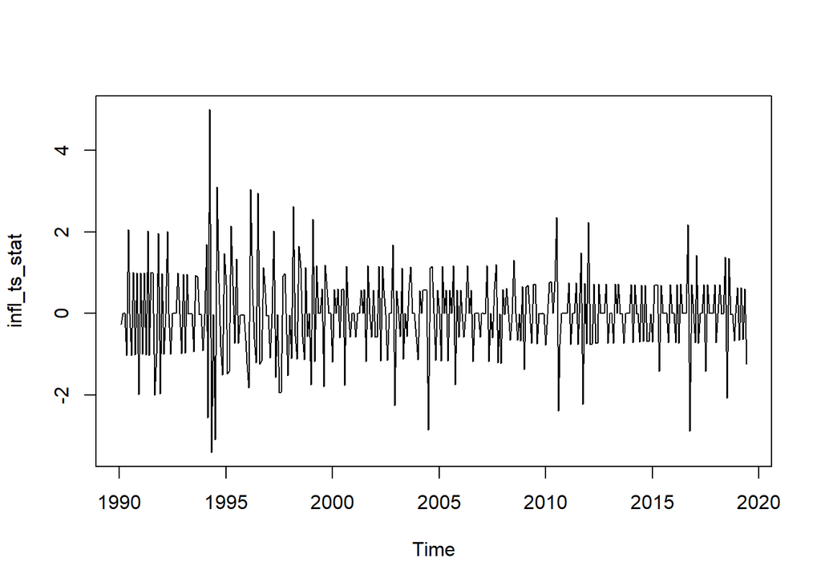

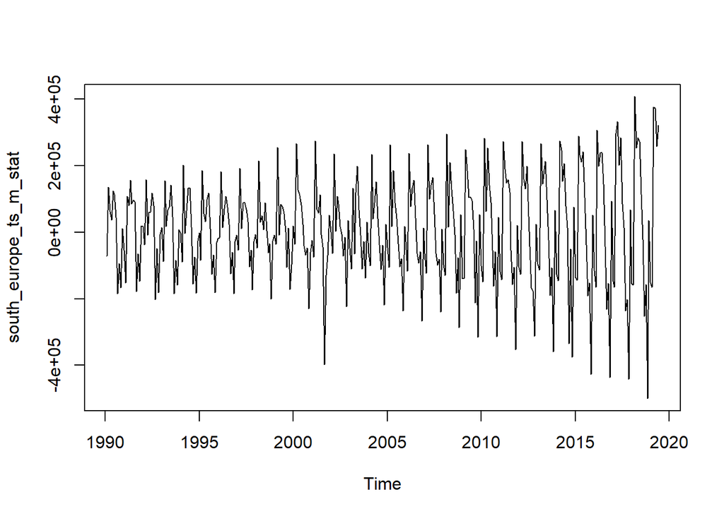

```
## AIC(n)  HQ(n)  SC(n) FPE(n)
##     12     12     12     12
```

```
##
## VAR Estimation Results:
## =========================
## Endogenous variables: train_travel, train_cpi, train_infl
## Deterministic variables: both
## Sample size: 122
## Log Likelihood: -1089.461
## Roots of the characteristic polynomial:
## 0.7297 0.6793 0.6793 0.6263 0.6263 0.6214 0.6214 0.6161 0.6161 0.5975 0.5975 0.3979
## Call:
## VAR(y = cbind(train_travel, train_cpi, train_infl), p = 4, type = "both",
##     season = 12L)
##
##
## Estimation results for equation train_travel:
## =============================================
## train_travel = train_travel.l1 + train_cpi.l1 + train_infl.l1 + train_travel.l2 + train_cpi.l2 + train_infl.l2 + train_travel.l3 + train_cpi.l3 + train_infl.l3 + train_travel.l4 + train_cpi.l4 + train_infl.l4 + const + trend + sd1 + sd2 + sd3 + sd4 + sd5 + sd6 + sd7 + sd8 + sd9 + sd10 + sd11
##
##                   Estimate Std. Error t value Pr(>|t|)
## train_travel.l1  4.034e-02  9.393e-02   0.430 0.668511
## train_cpi.l1     1.482e+06  8.994e+05   1.648 0.102612
## train_infl.l1   -1.964e+05  1.229e+05  -1.598 0.113295
## train_travel.l2  2.954e-01  9.506e-02   3.107 0.002476 **
## train_cpi.l2    -7.142e+05  1.040e+06  -0.686 0.494070
## train_infl.l2   -9.727e+04  1.224e+05  -0.795 0.428571
## train_travel.l3 -6.085e-02  9.762e-02  -0.623 0.534524
## train_cpi.l3    -4.767e+05  1.036e+06  -0.460 0.646532
## train_infl.l3   -2.738e+04  1.207e+05  -0.227 0.820962
## train_travel.l4 -1.275e-01  1.021e-01  -1.249 0.214691
## train_cpi.l4    -2.436e+05  8.832e+05  -0.276 0.783300
## train_infl.l4    7.832e+03  6.952e+03   1.127 0.262672
## const           -9.666e+02  1.023e+04  -0.095 0.924906
## trend            8.507e+01  1.356e+02   0.627 0.531897
## sd1             -1.424e+05  5.137e+04  -2.773 0.006660 **
## sd2             -2.764e+05  4.040e+04  -6.842 7.04e-10 ***
## sd3              1.976e+05  5.041e+04   3.920 0.000165 ***
## sd4              1.364e+05  6.549e+04   2.083 0.039888 *
## sd5             -2.002e+04  6.814e+04  -0.294 0.769577
## sd6              4.446e+04  7.426e+04   0.599 0.550781
## sd7             -9.992e+03  7.390e+04  -0.135 0.892733
```

[output cut: 88 more lines]

```
## F-statistic: 3.877 on 24 and 97 DF,  p-value: 1.054e-06
##
##
##
## Covariance matrix of residuals:
##              train_travel train_cpi train_infl
## train_travel    2.051e+09 31.329106  137.79322
## train_cpi       3.133e+01  0.007842    0.05713
## train_infl      1.378e+02  0.057126    0.41754
##
## Correlation matrix of residuals:
##              train_travel train_cpi train_infl
## train_travel     1.000000  0.007812   0.004709
## train_cpi        0.007812  1.000000   0.998296
## train_infl       0.004709  0.998296   1.000000
```

```
##
## VAR Estimation Results:
## =========================
## Endogenous variables: train_travel, train_cpi, train_infl
## Deterministic variables: both
## Sample size: 114
## Log Likelihood: -912.97
## Roots of the characteristic polynomial:
## 1.005 1.005 0.9339 0.9339 0.9275 0.9275 0.9268 0.9268 0.9254 0.9254 0.9246 0.9246 0.9218 0.9218 0.8958 0.8958 0.8645 0.8522 0.8522 0.8424 0.8424 0.8407 0.8407 0.8351 0.8351 0.8351 0.8351 0.8304 0.8304 0.7967 0.7868 0.7868 0.7721 0.7721 0.6027 0.6027
## Call:
## VAR(y = cbind(train_travel, train_cpi, train_infl), p = 12, type = "both",
##     season = 12L)
##
##
## Estimation results for equation train_travel:
## =============================================
## train_travel = train_travel.l1 + train_cpi.l1 + train_infl.l1 + train_travel.l2 + train_cpi.l2 + train_infl.l2 + train_travel.l3 + train_cpi.l3 + train_infl.l3 + train_travel.l4 + train_cpi.l4 + train_infl.l4 + train_travel.l5 + train_cpi.l5 + train_infl.l5 + train_travel.l6 + train_cpi.l6 + trai…
##
##                    Estimate Std. Error t value Pr(>|t|)
## train_travel.l1  -3.999e-01  1.239e-01  -3.228 0.001957 **
## train_cpi.l1      3.354e+04  1.008e+06   0.033 0.973565
## train_infl.l1     6.068e+03  1.373e+05   0.044 0.964885
## train_travel.l2  -1.532e-01  1.321e-01  -1.160 0.250292
## train_cpi.l2      1.153e+06  1.125e+06   1.025 0.309330
## train_infl.l2    -1.516e+05  1.496e+05  -1.013 0.314736
## train_travel.l3  -2.381e-01  1.355e-01  -1.757 0.083612 .
## train_cpi.l3     -8.329e+04  1.157e+06  -0.072 0.942822
## train_infl.l3    -1.335e+05  1.540e+05  -0.867 0.389178
## train_travel.l4   1.069e-02  1.395e-01   0.077 0.939163
## train_cpi.l4     -1.037e+05  1.157e+06  -0.090 0.928892
## train_infl.l4    -1.186e+05  1.536e+05  -0.772 0.442756
## train_travel.l5  -3.789e-01  1.358e-01  -2.789 0.006925 **
## train_cpi.l5     -1.076e+06  1.147e+06  -0.938 0.351681
## train_infl.l5     2.316e+04  1.536e+05   0.151 0.880629
## train_travel.l6  -3.694e-01  1.255e-01  -2.942 0.004509 **
## train_cpi.l6      1.682e+05  1.050e+06   0.160 0.873273
## train_infl.l6    -6.877e+03  1.335e+05  -0.051 0.959087
## train_travel.l7  -4.366e-01  1.304e-01  -3.349 0.001352 **
## train_cpi.l7      6.125e+05  9.392e+05   0.652 0.516566
## train_infl.l7    -7.980e+04  1.375e+05  -0.580 0.563793
```

[output cut: 160 more lines]

```
## F-statistic:  2.55 on 48 and 65 DF,  p-value: 0.0002365
##
##
##
## Covariance matrix of residuals:
##              train_travel train_cpi train_infl
## train_travel    1.270e+09 236.48063  1.661e+03
## train_cpi       2.365e+02   0.00753  5.515e-02
## train_infl      1.661e+03   0.05515  4.049e-01
##
## Correlation matrix of residuals:
##              train_travel train_cpi train_infl
## train_travel      1.00000   0.07647    0.07324
## train_cpi         0.07647   1.00000    0.99872
## train_infl        0.07324   0.99872    1.00000
```

- Based on the AIC, the VAR(12) should be selected

```
##
##  Portmanteau Test (asymptotic)
##
## data:  Residuals of VAR object var_model_1
## Chi-squared = 82.287, df = 54, p-value = 0.007854
```

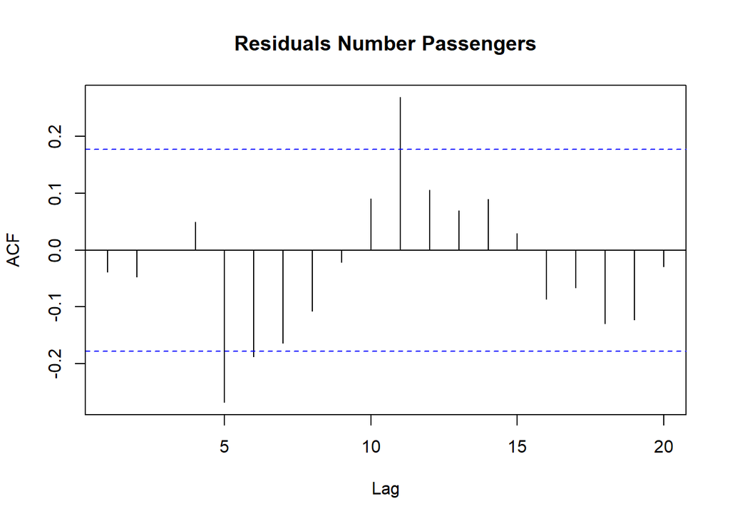

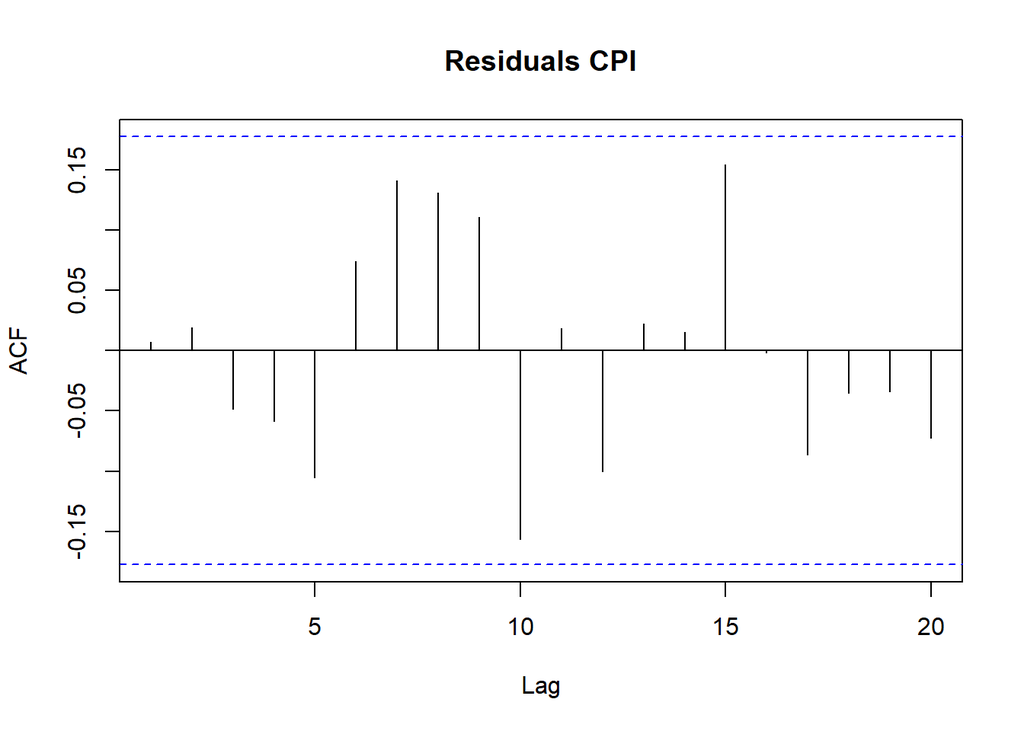

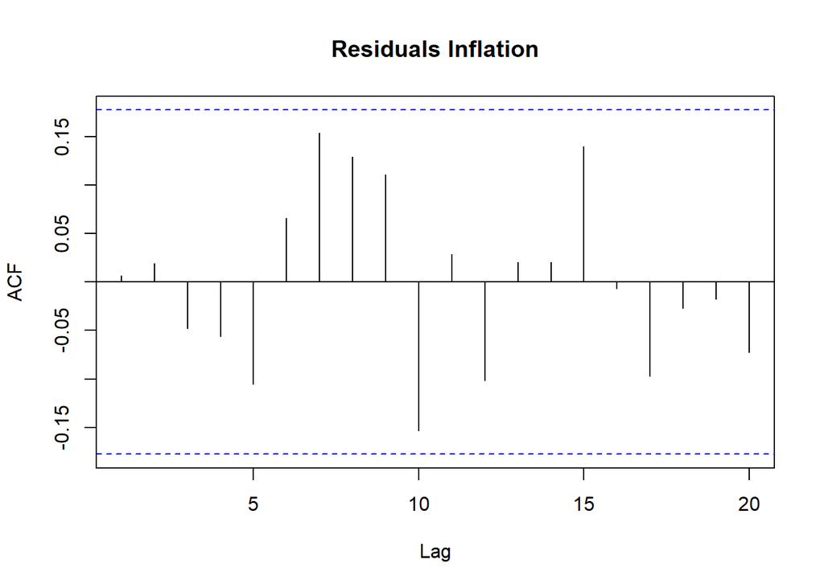

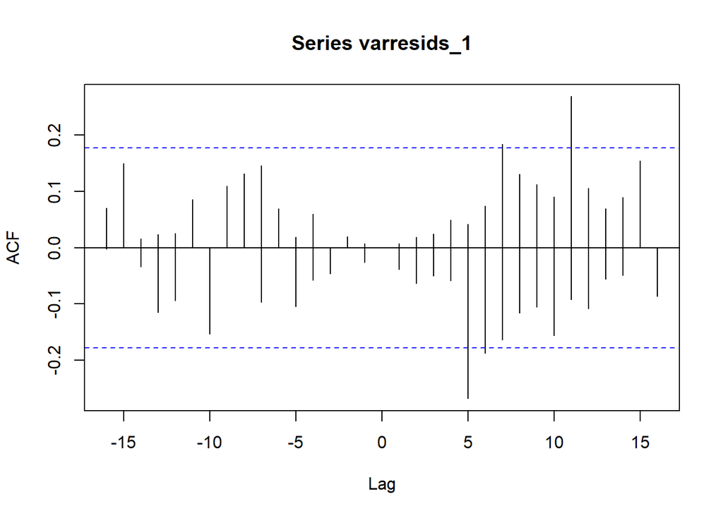

```
##
##  Portmanteau Test (asymptotic)
##
## data:  Residuals of VAR object var_model_2
## Chi-squared = 42.936, df = -18, p-value = NA
```

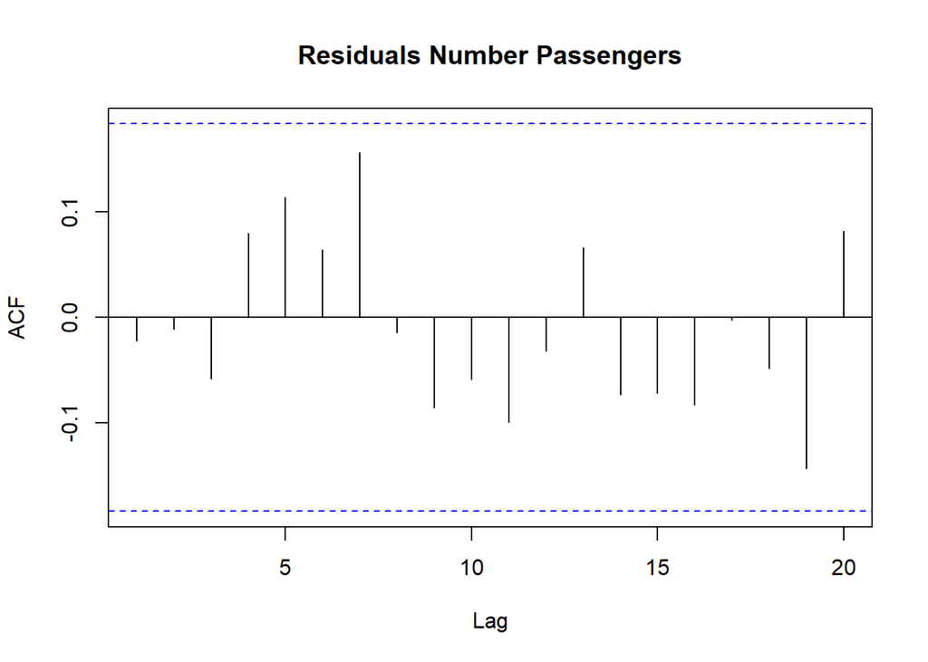

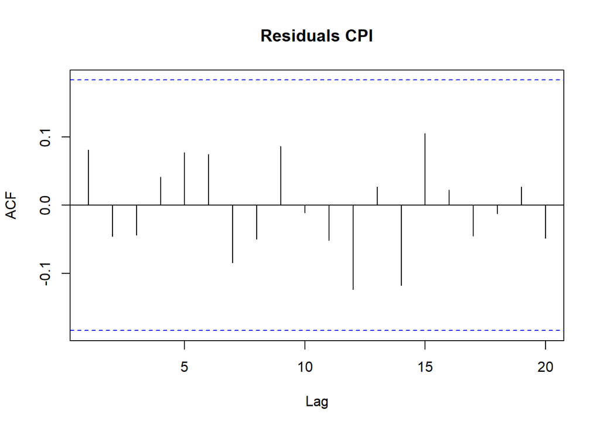

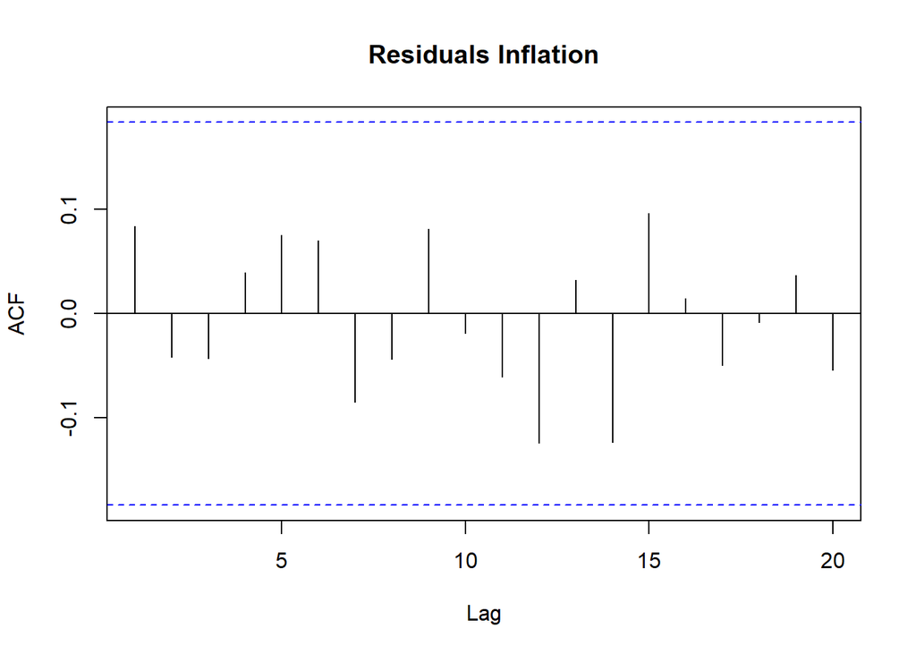